# Predicting Cancer Mortality Rate by State

Margaret Gacheru (mg3861), Annie Clark (alc2279), Keyanna Davis (kd2640), Tian Li (tl2882)

December 17, 2018

Load the cancer registry data

```r
cancer_data = read_csv(file = "./data/Cancer_Registry.csv") %>%
  janitor::clean_names()
```

# Data Exploration (County Level)

Obtain summary statistics for all variables at the county level

```r
numerical = cancer_data%>%
  dplyr::select(-c(binned_inc, geography))

Minimum = sapply(numerical, min, na.rm = 'TRUE')
Maximum = sapply(numerical, max, na.rm = 'TRUE')
Mean = sapply(numerical, mean, na.rm = 'TRUE')
Median = sapply(numerical, median, na.rm = 'TRUE')
SD = sapply(numerical, sd, na.rm = 'TRUE')
IQR = sapply(numerical, IQR, na.rm='TRUE')
Size = sapply(numerical, length)
Missing = sapply(numerical, function(x) sum(is.na(x)))

rbind(Minimum, Maximum, Mean, SD, Median, IQR, Size, Missing) %>%
  round(digits = 2)%>%t()
```

```
##                             Minimum     Maximum      Mean        SD
## avg_ann_count                  6.00    38150.00    606.34   1416.36
## avg_deaths_per_year            3.00    14010.00    185.97    504.13
## target_death_rate             59.70      362.80    178.66     27.75
## incidence_rate               201.30     1206.90    448.27     54.56
## med_income                 22640.00   125635.00  47063.28  12040.09
## pop_est2015                  827.00 10170292.00 102637.37 329059.22
## poverty_percent                3.20       47.40     16.88      6.41
## study_per_cap                  0.00     9762.31    155.40    529.63
## median_age                    22.30      624.00     45.27     45.30
## median_age_male               22.40       64.70     39.57      5.23
## median_age_female             22.30       65.70     42.15      5.29
## avg_household_size             0.02        3.97      2.48      0.43
## percent_married               23.10       72.50     51.77      6.90
## pct_no_hs18_24                 0.00       64.10     18.22      8.09
## pct_hs18_24                    0.00       72.50     35.00      9.07
## pct_some_col18_24              7.10       79.00     40.98     11.12
## pct_bach_deg18_24              0.00       51.80      6.16      4.53
## pct_hs25_over                  7.50       54.80     34.80      7.03
## pct_bach_deg25_over            2.50       42.20     13.28      5.39
## pct_employed16_over           17.60       80.10     54.15      8.32
## pct_unemployed16_over          0.40       29.40      7.85      3.45
## pct_private_coverage          22.30       92.30     64.35     10.65
## pct_private_coverage_alone    15.70       78.90     48.45     10.08
## pct_emp_priv_coverage         13.50       70.70     41.20      9.45
## pct_public_coverage           11.20       65.10     36.25      7.84
## pct_public_coverage_alone      2.60       46.60     19.24      6.11
## pct_white                     10.20      100.00     83.65     16.38
## pct_black                      0.00       85.95      9.11     14.53
## pct_asian                      0.00       42.62      1.25      2.61
## pct_other_race                 0.00       41.93      1.98      3.52
## pct_married_households        22.99       78.08     51.24      6.57
## birth_rate                     0.00       21.33      5.64      1.99
##                              Median      IQR Size Missing
## avg_ann_count                171.00   442.00 3047       0
## avg_deaths_per_year           61.00   121.00 3047       0
## target_death_rate            178.10    34.00 3047       0
## incidence_rate               453.55    60.55 3047       0
## med_income                 45207.00 13609.50 3047       0
## pop_est2015                26643.00 56987.00 3047       0
```

[output cut: 11 more lines]

```
## pct_hs25_over                 35.30     9.25 3047       0
## pct_bach_deg25_over           12.30     6.70 3047       0
## pct_employed16_over           54.50    11.70 3047     152
## pct_unemployed16_over          7.60     4.20 3047       0
## pct_private_coverage          65.10    14.90 3047       0
## pct_private_coverage_alone    48.70    14.60 3047     609
## pct_emp_priv_coverage         41.10    13.20 3047       0
## pct_public_coverage           36.30    10.65 3047       0
## pct_public_coverage_alone     18.80     8.25 3047       0
## pct_white                     90.06    18.16 3047       0
## pct_black                      2.25     9.89 3047       0
## pct_asian                      0.55     0.97 3047       0
## pct_other_race                 0.83     1.88 3047       0
## pct_married_households        51.67     7.63 3047       0
## birth_rate                     5.38     1.97 3047       0
```

Note that pct_some_col18_24 has 2285 out of 3047 missing values (75%), pct_employed16_over has 152 out of 3047 missing values (5%), and pct_private_coverage_alone has 609 out of 3047 missing values (20%). Some college has too many missing values so it might be advisable not include it in the list of potential covariates

Since pct_some_col18_24 had a high percentage of missing data, remove the variable from the dataset. Furthermore, remove observations that have missing values for pct_private_coverage_alone and pct_employed16_over.

```r
clean_cancer_data = cancer_data%>%
  dplyr::select(-pct_some_col18_24)%>%
  na.omit()
```

From literature review and preliminary discussions, remove binned_inc, pct_some_col_18_24, median_age, geography, avg_deaths_per_year, and pop_est_2015 from the dataset

```r
reduced_clean = clean_cancer_data%>%
  dplyr::select(-c(binned_inc, geography, median_age, avg_deaths_per_year, pop_est2015))
```

median_age is removed because of its unrealistic values (extreme outliers)

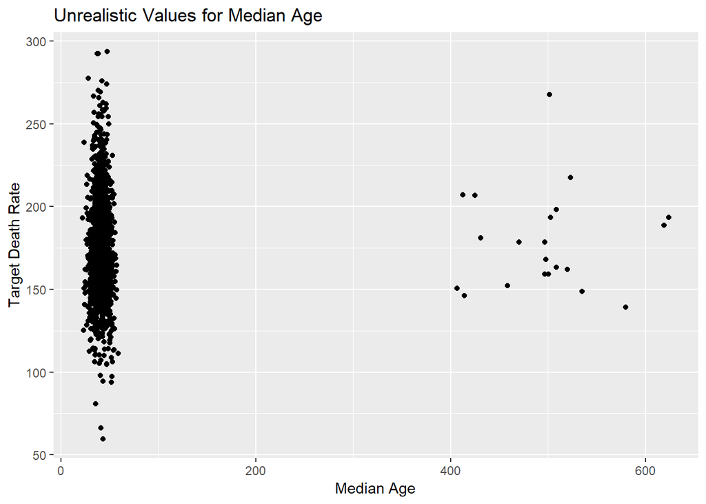

```r
clean_cancer_data%>%
  ggplot(aes(x = median_age, y = target_death_rate))+
  geom_point()+
  labs(title  = "Unrealistic Values for Median Age",
      x = "Median Age",
      y = "Target Death Rate")
```

Next, find out if there are variables that are highly correlated/provide the same information

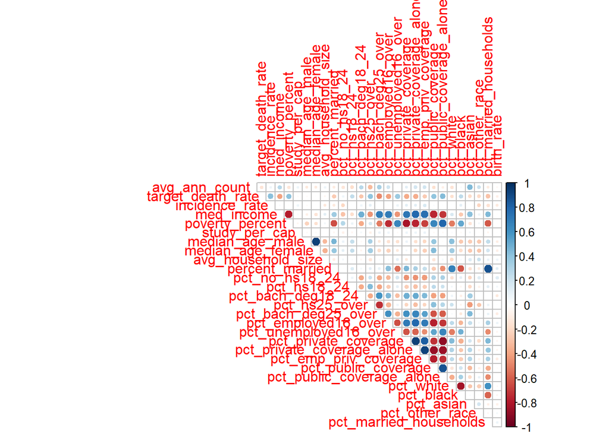

```r
par(mfrow=c(1,1))
cor(reduced_clean)%>%
  corrplot(method = "circle", type = "upper", diag=FALSE)
```

The main takeaways from the correlation plot is that there are moderate to strong correlations between variables that provide information on income, insurance, employment, and bachelor degree. This is to be expected since all the mentioned variables can be measures of SES. In addition, there is a strong correlation between black and white as well as between percentage of married and percent of married households

Now, observe the distributions of potential covariates and observe if transformations are needed in the case our variables are skewed

Create a function that plots and performs tranformations on the variables

```r
distribution = function(variable) {

  reduced_clean = tibble(variable)

  reduced_clean%>%
    ggplot(aes(variable))+
    geom_histogram()
}

inspection = function(variable) {

  reduced_clean = tibble(variable)

  #Observe transformations

  transformations = reduced_clean%>%
    dplyr::select(variable)%>%
    mutate(log_variable = log(variable),
          sqrt_variable = sqrt(variable),
          inverse_variable = 1 / variable)%>%
    gather(key = type, value = value)

  a = transformations%>%
    filter(type == "variable")%>%
    ggplot(aes(value))+
    geom_density()+
    labs(x = "Original",
        y = "Frequency")

  b = transformations%>%
    filter(type == "sqrt_variable")%>%
    ggplot(aes(value))+
    geom_density()+
    labs(x = "Sqrt(Variable)",
        y = "Frequency")

  c = transformations%>%
    filter(type == "inverse_variable")%>%
    ggplot(aes(value))+
    geom_density()+
    labs(x = "Inverse(Variable)",
        y = "Frequency")

  d = transformations%>%
    filter(type == "log_variable")%>%
    ggplot(aes(value))+
    geom_density()+
    labs(x = "log(Variable)",
        y = "Frequency")

  (a + b) / (c + d)

}
```

### Distributions and Transformations

Average annual count has one extreme outlier, making the distribution of the points to be right skewed. Log tranformation most reduces the skewness

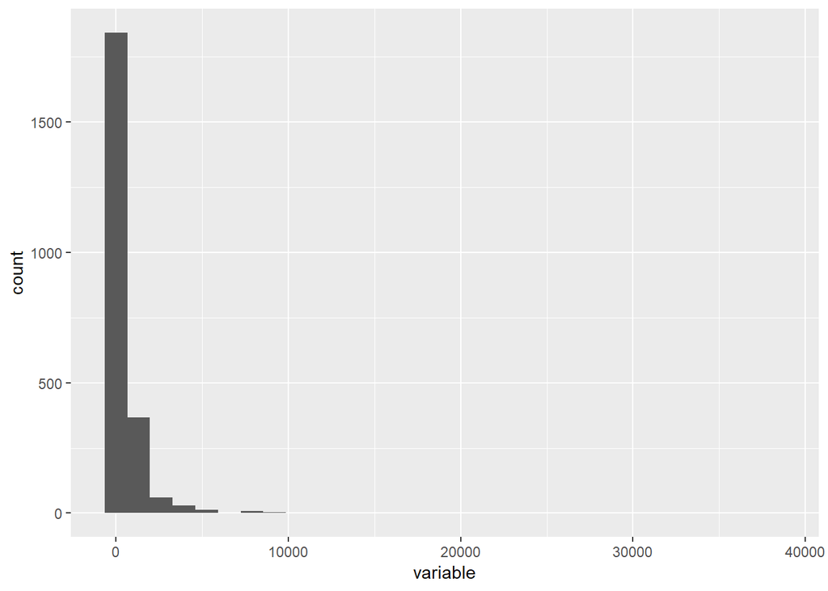

```r
variable = reduced_clean$avg_ann_count

distribution(variable)
```

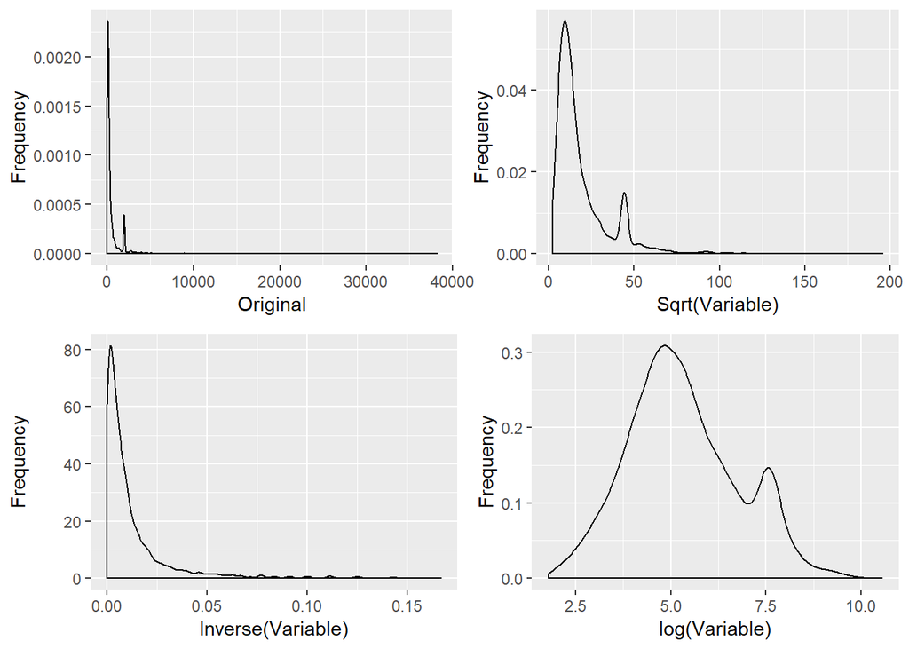

```r
inspection(variable)
```

The distribution of incidence rate seems to be appropriately clustered, with a few outliers. Transformations result in similar shapes as the original

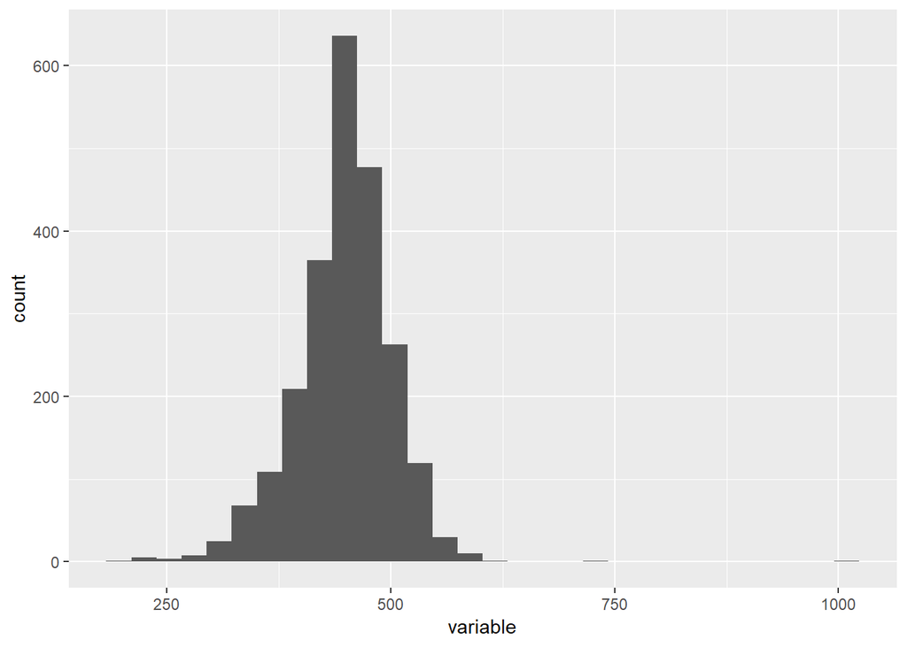

```r
variable = reduced_clean$incidence_rate

distribution(variable)
```

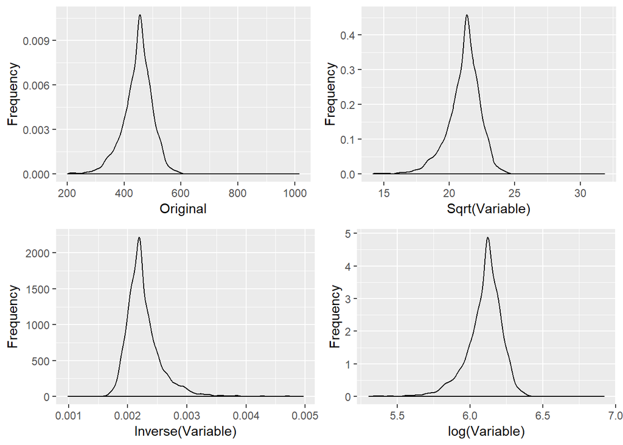

```r
inspection(variable)
```

Median income is slighly right skewed and the inverse transformation reduces most of the skewness. Transformation also may not be necessary in this case

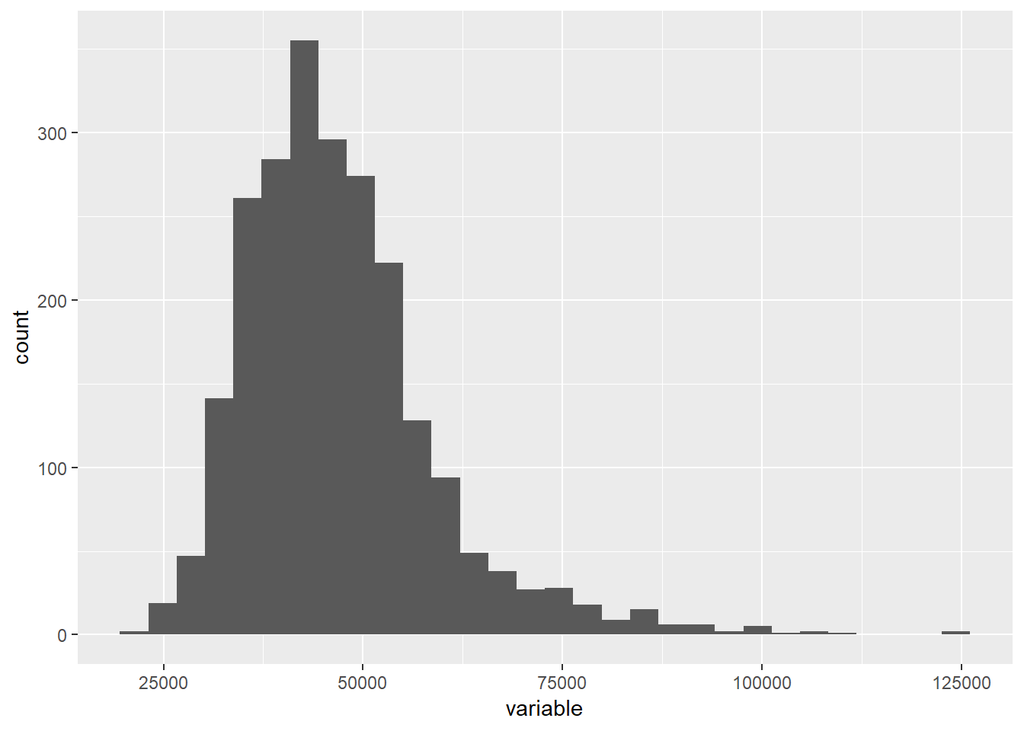

```r
variable = reduced_clean$med_income

distribution(variable)
```

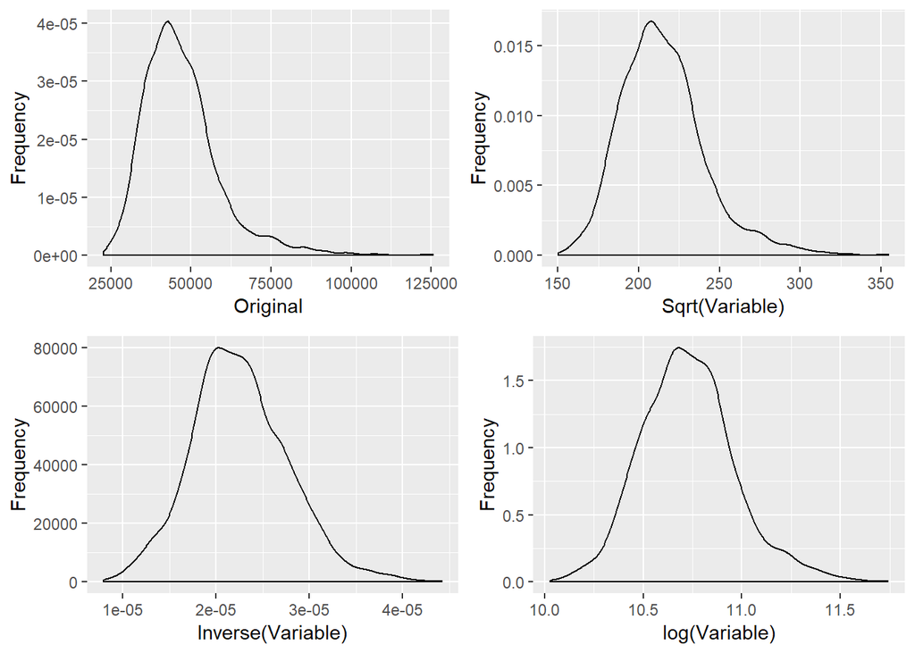

```r
inspection(variable)
```

Poverty percent is slightly right skewed and the square root transformation reduces most of the skewness. Transformation also may not be necessary in this case

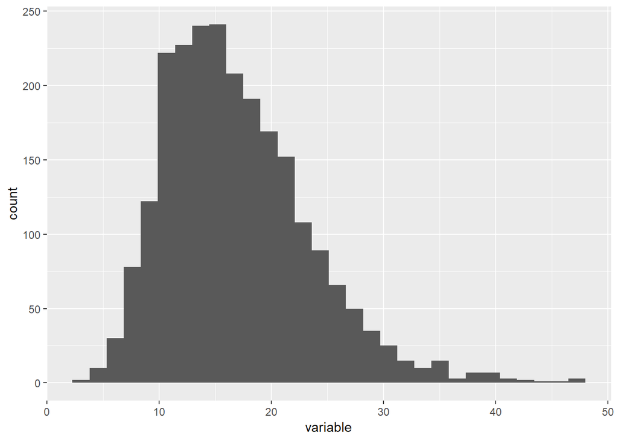

```r
variable = reduced_clean$poverty_percent

distribution(variable)
```

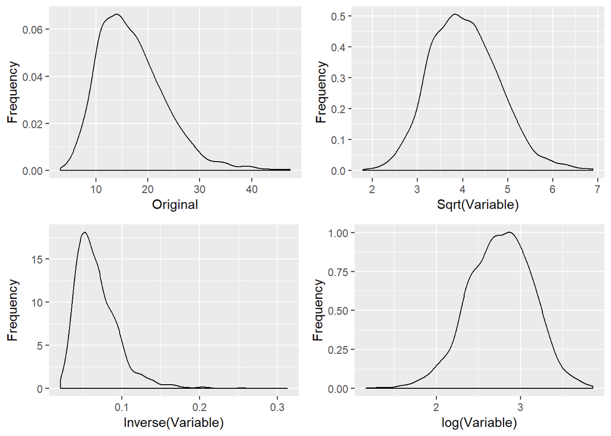

```r
inspection(variable)
```

Study per cap is highly right skewed and the log transformation reduces most of the skewness

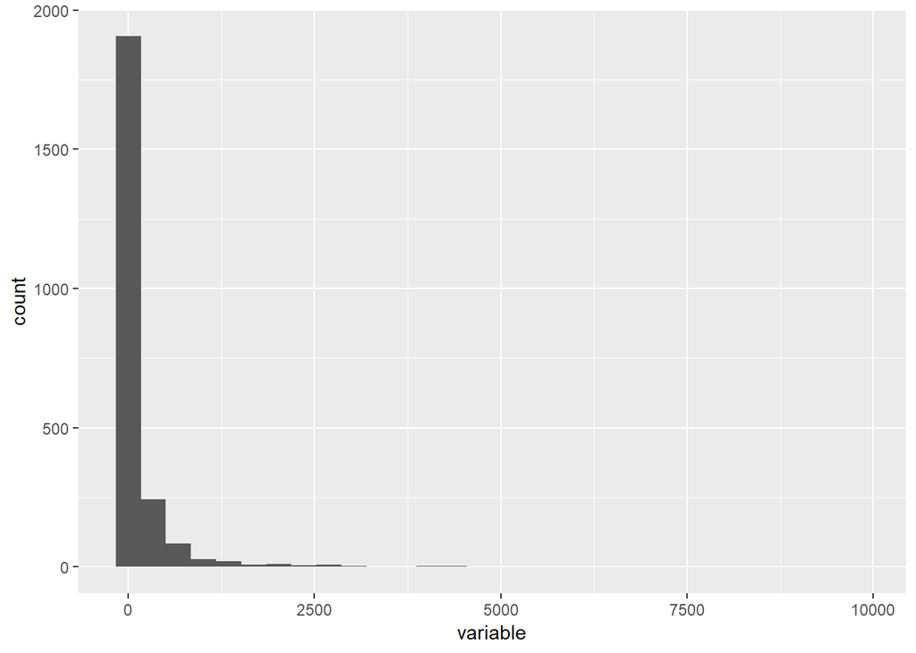

```r
variable = reduced_clean$study_per_cap

distribution(variable)
```

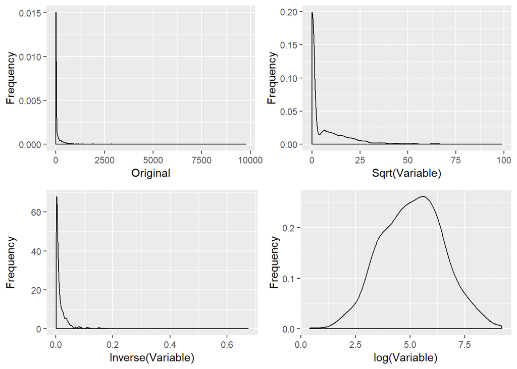

```r
inspection(variable)
```

Median age for males has an appropriate shape and does not need transformation

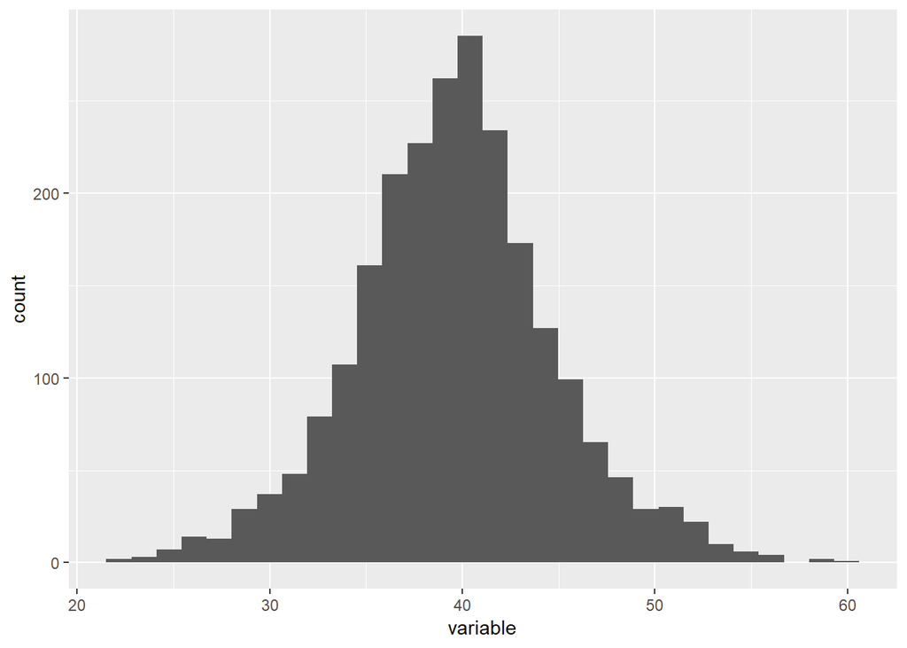

```r
variable = reduced_clean$median_age_male

distribution(variable)
```

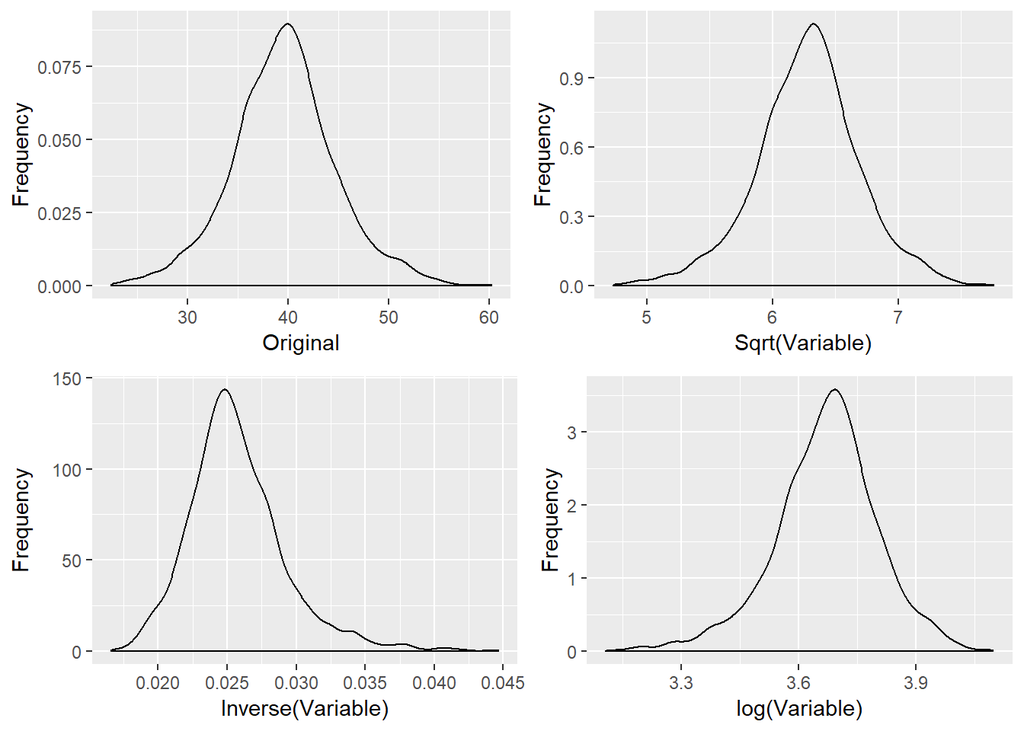

```r
inspection(variable)
```

Median age for females has an appropriate shape and does not need transformation

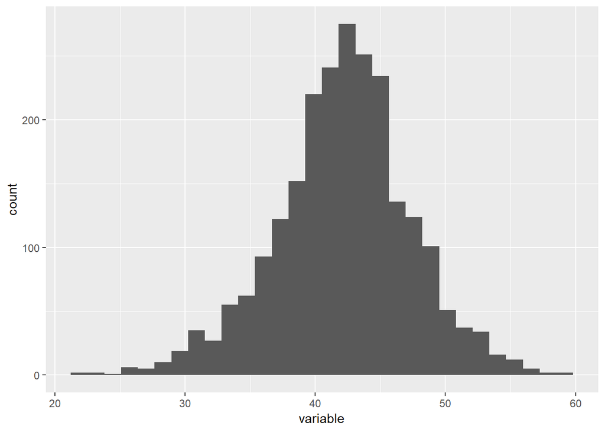

```r
variable = reduced_clean$median_age_female

distribution(variable)
```

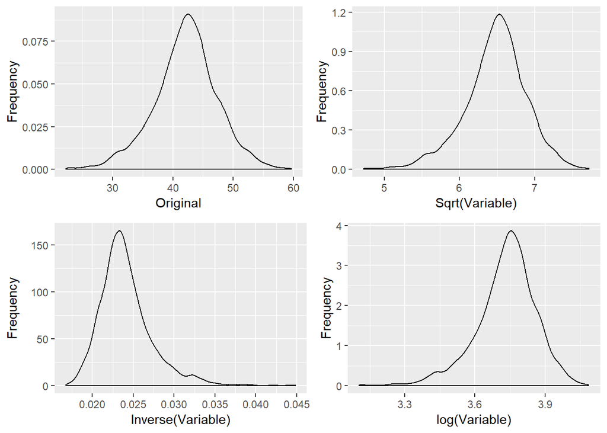

```r
inspection(variable)
```

Average household size has some unusual values. A majority of the points are clustured around 2.5 and there is a slight skewness to the right. However, there are some outliers to the left that are close to 0. None of the transformations are useful - the log transformation removes the slight right skewness but we still see a another bump to the left

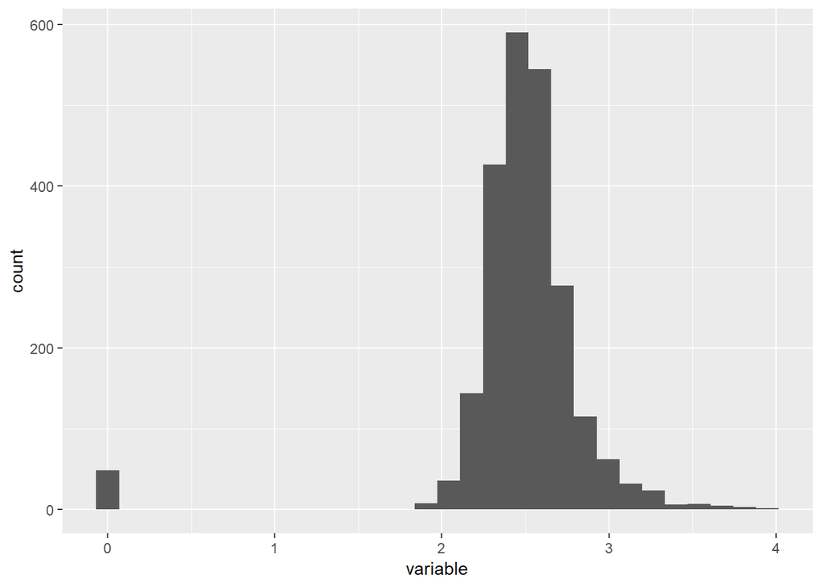

```r
variable = reduced_clean$avg_household_size

distribution(variable)
```

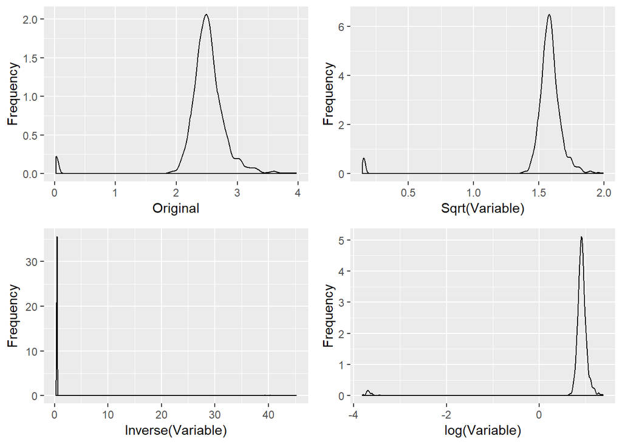

```r
inspection(variable)
```

Percent married is slightly left skewed but none of the transformation perform better, in terms of skewness

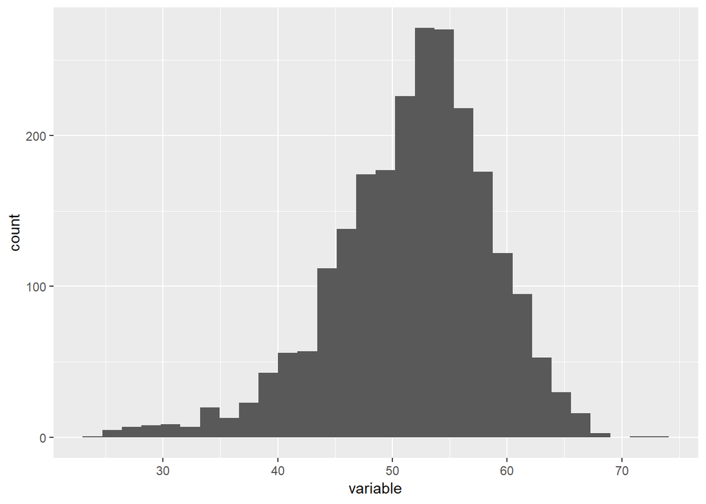

```r
variable = reduced_clean$percent_married

distribution(variable)
```

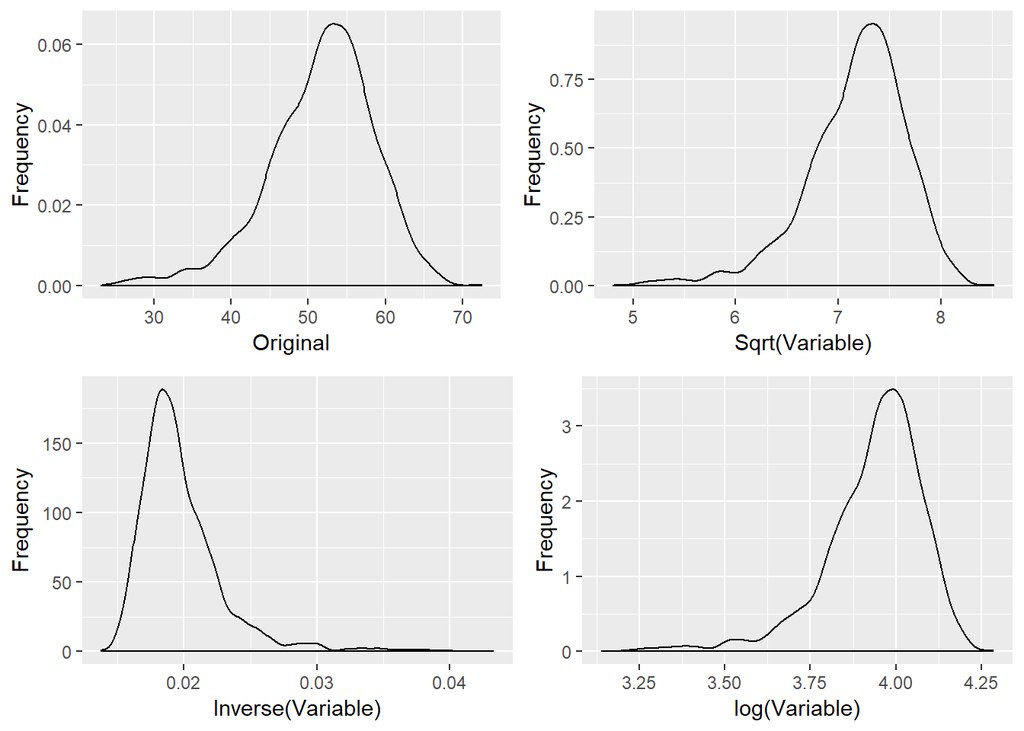

```r
inspection(variable)
```

pct_no_hs18_24 is slightly right skewed and the square root transformation reduces most of the skewness. However, a transformation might not be necessary in this case

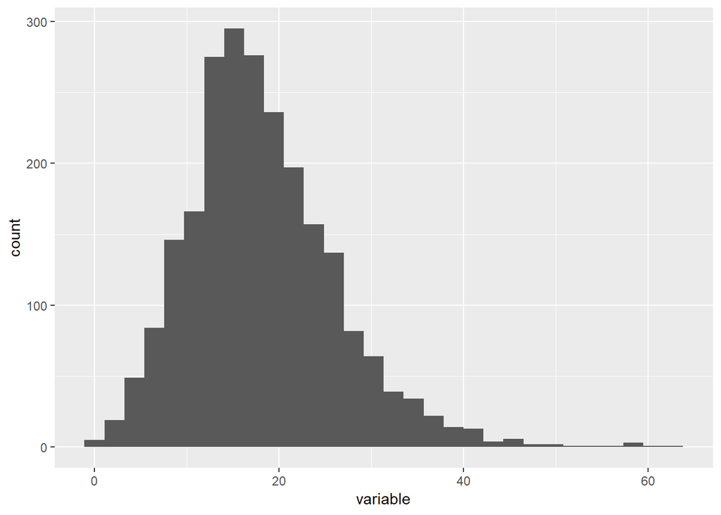

```r
variable = reduced_clean$pct_no_hs18_24


distribution(variable)
```

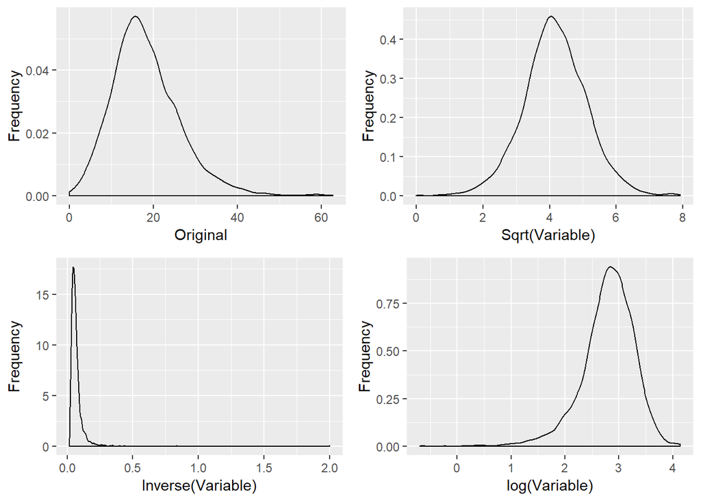

```r
inspection(variable)
```

pct_hs18_24 is appropriately shaped

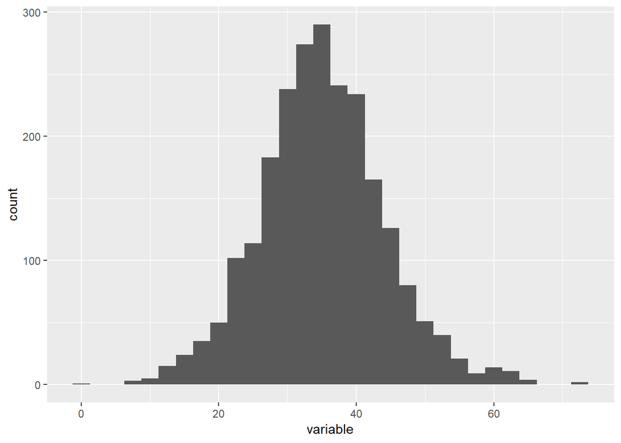

```r
variable = reduced_clean$pct_hs18_24


distribution(variable)
```

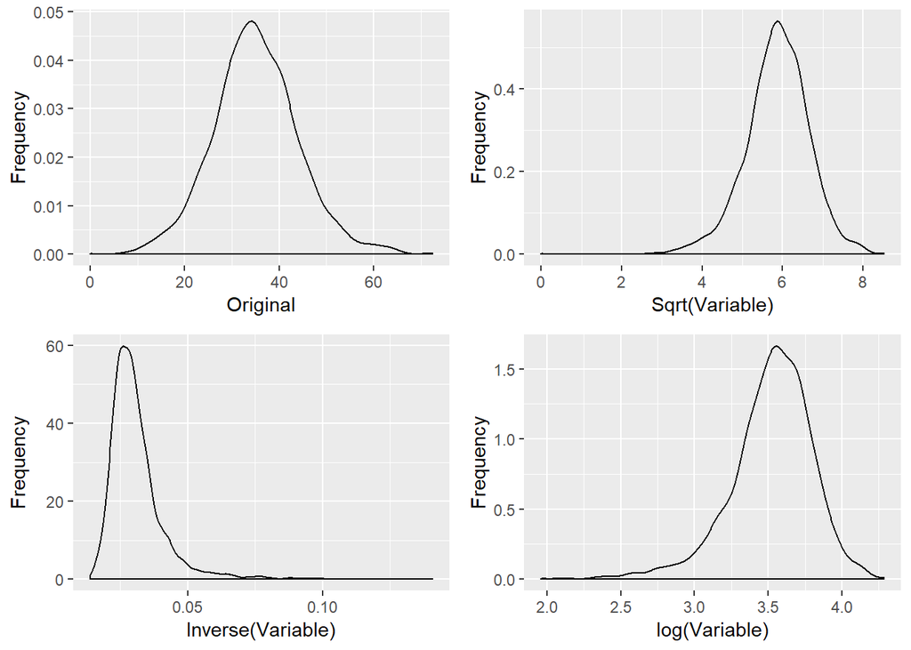

```r
inspection(variable)
```

pct_bach_deg18_24 is right skewed. While the square root transformation reduces most of the skewness, it also creates a second peak close to zero.

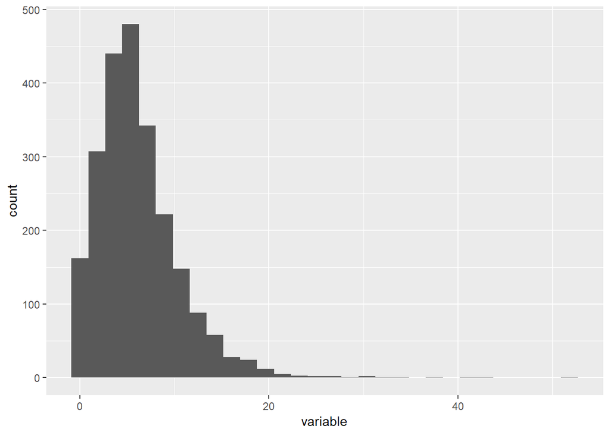

```r
variable = reduced_clean$pct_bach_deg18_24


distribution(variable)
```

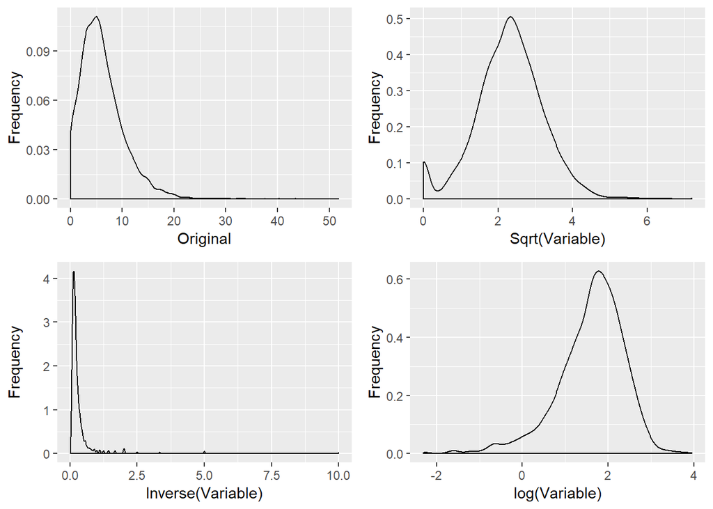

```r
inspection(variable)
```

pct_hs25_over is very slightly left skewed and no transformation is necessary

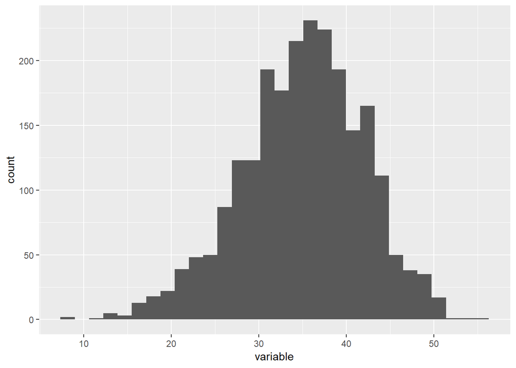

```r
variable = reduced_clean$pct_hs25_over


distribution(variable)
```

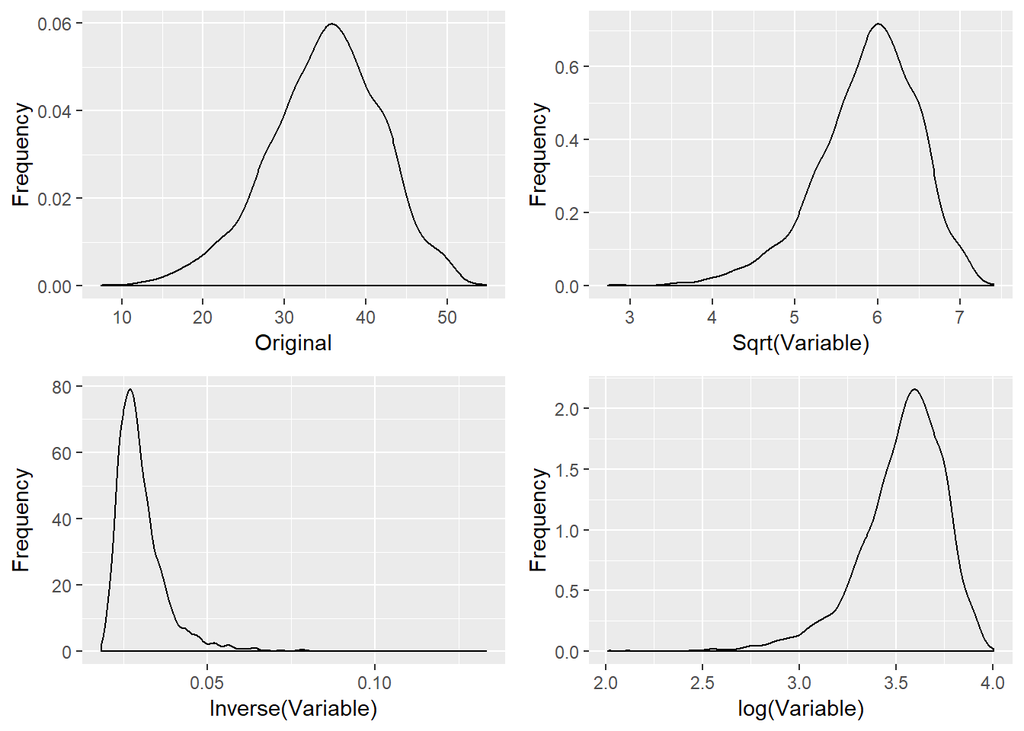

```r
inspection(variable)
```

pct_bach_deg25_over is right skewed and a log transformation best reduces the skewness

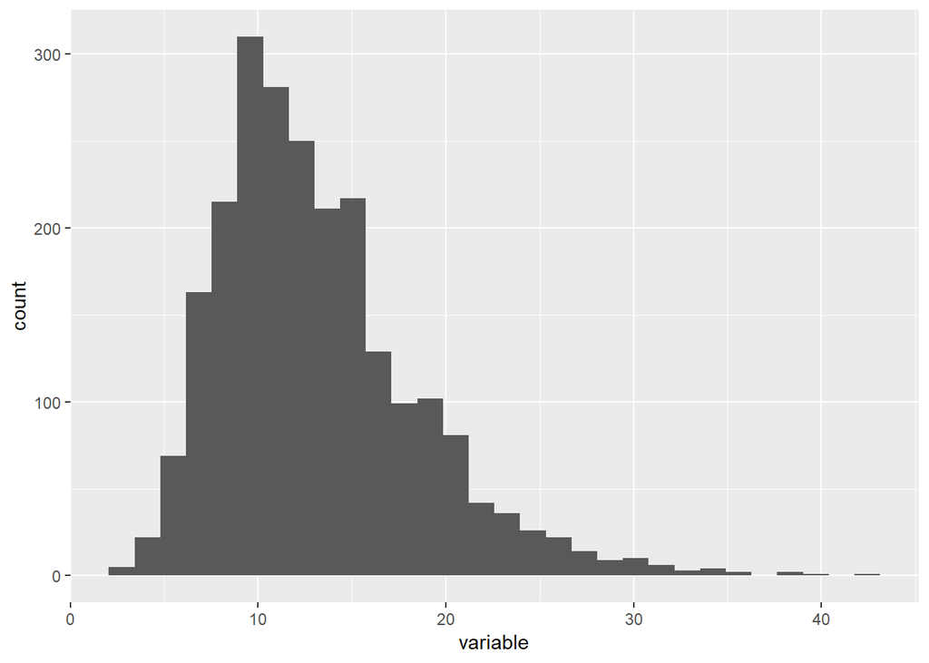

```r
variable = reduced_clean$pct_bach_deg25_over


distribution(variable)
```